# drama_casting_strategy

202016222 통계학과 류태영, 202321036 통계학과 정채연, 202021297 통계학과 국철훈

2025-04-20

🎬 1. 연구 배경 사극은 배우의 연기력과 인지도가 시청률에 큰 영향

특히 조선 시대 왕 중심 드라마는 반복적으로 제작됨

배우 캐스팅은 흥행과 배우 커리어 모두에 결정적 역할

→ 배우 출연 후 커리어 흐름 분석 필요

🎯 2. 연구 목적 조선 왕 관련 사극의 캐스팅 전략을 데이터 기반으로 분석

배우 출연작의 시청률 흐름을 정량적으로 추적

사극 출연이 배우 커리어에 끼친 영향 평가

출연 이후 드라마 평점, 히트작 여부 등을 종합 점수화

→ 배우 캐스팅 시 참고 가능한 지표 제공

① 조선 왕 목록 수집 (Wikipedia 크롤링)

```r
library(stringr)
library(dplyr)
```

```r
library(ggplot2)
library(tidyverse)
library(tidytext)
library(tidyr)
library(purrr)
library(tibble)
library(rvest)
library(readr)
library(httr)
library(RSelenium)
library(progress)
library(furrr)
library(future.apply)

# 국왕 목록 페이지
main_url <- "https://ko.wikipedia.org/wiki/조선_국왕"
page <- read_html(main_url)

# 국왕 이름과 링크 추출
king_nodes <- page %>%
  html_nodes("table.wikitable tbody tr td:nth-child(2) a")

king_df <- tibble(
  king = king_nodes %>% html_text(trim = TRUE),
  url = king_nodes %>% html_attr("href") %>% paste0("https://ko.wikipedia.org", .)
) %>%
  filter(king != "")  # 빈 이름 제거

# 결과 확인
print(king_df,n=10)
```

```
## # A tibble: 26 × 2
##    king   url
##    <chr>  <chr>
##  1 태조   https://ko.wikipedia.org/wiki/%ED%83%9C%EC%A1%B0_(%EC%A1%B0%EC%84%A0)
##  2 정종   https://ko.wikipedia.org/wiki/%EC%A0%95%EC%A2%85_(%EC%A1%B0%EC%84%A0)
##  3 태종   https://ko.wikipedia.org/wiki/%ED%83%9C%EC%A2%85_(%EC%A1%B0%EC%84%A0)
##  4 세종   https://ko.wikipedia.org/wiki/%EC%84%B8%EC%A2%85_(%EC%A1%B0%EC%84%A0)
##  5 문종   https://ko.wikipedia.org/wiki/%EB%AC%B8%EC%A2%85_(%EC%A1%B0%EC%84%A0)
##  6 단종   https://ko.wikipedia.org/wiki/%EB%8B%A8%EC%A2%85_(%EC%A1%B0%EC%84%A0)
##  7 세조   https://ko.wikipedia.org/wiki/%EC%84%B8%EC%A1%B0_(%EC%A1%B0%EC%84%A0)
##  8 예종   https://ko.wikipedia.org/wiki/%EC%98%88%EC%A2%85_(%EC%A1%B0%EC%84%A0)
##  9 성종   https://ko.wikipedia.org/wiki/%EC%84%B1%EC%A2%85_(%EC%A1%B0%EC%84%A0)
## 10 연산군 https://ko.wikipedia.org/wiki/%EC%97%B0%EC%82%B0%EA%B5%B0
## # ℹ 16 more rows
```

② 왕별 드라마 리스트 수집 (HTML 구조별 파싱)

```r
# STEP 3: 드라마 정보 추출 함수 (테이블 + 리스트 모두 처리)
extract_dramas <- function(url, king_name) {
  page <- tryCatch(read_html(url), error = function(e) return(NULL))
  if (is.null(page)) return(NULL)

  # "드라마"라는 텍스트가 들어간 h3를 포함하는 div 찾기
  drama_divs <- page %>%
    html_nodes(xpath = "//div[h3[contains(text(), '드라마')]]")

  if (length(drama_divs) == 0) return(NULL)

  result <- list()

  for (div in drama_divs) {
    #1️⃣ table 형태 (wikitable 클래스 테이블)
    table_node_wikitable <- div %>%
      html_nodes(xpath = "following-sibling::*[self::table[contains(@class, 'wikitable')]][1]")

    if (length(table_node_wikitable) > 0) {
      table_df <- tryCatch(html_table(table_node_wikitable, fill = TRUE)[[1]], error = function(e) NULL)
      if (!is.null(table_df)) {
        drama_texts <- apply(table_df, 1, function(row) paste(row, collapse = " | "))
        table_df <- data.frame(
          king = king_name,
          drama_info = drama_texts,
          stringsAsFactors = FALSE
        )
        result <- append(result, list(table_df))
      }
    }

    # 2️⃣ ul 형태
    ul_node <- div %>%
      html_nodes(xpath = "following-sibling::*[self::ul][1]")

    if (length(ul_node) > 0) {
      items <- ul_node %>%
        html_nodes("li") %>%
        html_text(trim = TRUE)
      if (length(items) > 0) {
        ul_df <- data.frame(
          king = king_name,
          drama_info = items,
          stringsAsFactors = FALSE
        )
        result <- append(result, list(ul_df))
      }
    }

    # 3️⃣ 일반 div 안에 텍스트 형태로 드라마 정보가 있는 경우
    text_div <- div %>%
      html_nodes(xpath = "following-sibling::*[self::div][1]")

    if (length(text_div) > 0) {
      text_items <- text_div %>%
        html_text(trim = TRUE) %>%
        strsplit("\n") %>%
        unlist() %>%
        str_trim() %>%
        discard(~ .x == "")  # 빈 줄 제거

      if (length(text_items) > 0) {
        text_df <- data.frame(
          king = king_name,
          drama_info = text_items,
          stringsAsFactors = FALSE
        )
        result <- append(result, list(text_df))
      }
    }
  }

  if (length(result) > 0) return(bind_rows(result)) else return(NULL)
}


# STEP 4: 모든 왕에 대해 수집 실행
all_dramas <- map2_dfr(king_df$url, king_df$king, extract_dramas)

# STEP 5: 확인 및 저장
print(head(all_dramas, 10))
```

```
##    king                                drama_info
## 1  태조            1967년 | TBC | 이성계 | 김성원
## 2  태조            1976년 | MBC | 예성강 | 이대근
## 3  태조             1983년 | KBS1 | 개국 | 임동진
## 4  태조       1983년 | MBC | 추동궁 마마 | 김무생
## 5  태조 1996년~1998년 | KBS1 | 용의 눈물 | 김무생
## 6  태조  2003년~2004년 | KBS1 | 무인시대 | 박용우
## 7  태조       2005년~2006년 | MBC | 신돈 | 이진우
## 8  태조              2012년 | SBS | 신의 | 오재무
## 9  태조     2012년~2013년 | SBS | 대풍수 | 지진희
## 10 태조           2014년 | KBS1 | 정도전 | 유동근
```

```r
write.csv(all_dramas, "조선왕조_드라마정보_정제본.csv", row.names = FALSE)
```

③ 배우, 방송사, 연도 등 정제

```r
# 1. 파일 불러오기
dramas <- read_csv("조선왕조_드라마정보_정제본.csv")
print(dramas)
```

```
## # A tibble: 311 × 2
##    king  drama_info
##    <chr> <chr>
##  1 태조  1967년 | TBC | 이성계 | 김성원
##  2 태조  1976년 | MBC | 예성강 | 이대근
##  3 태조  1983년 | KBS1 | 개국 | 임동진
##  4 태조  1983년 | MBC | 추동궁 마마 | 김무생
##  5 태조  1996년~1998년 | KBS1 | 용의 눈물 | 김무생
##  6 태조  2003년~2004년 | KBS1 | 무인시대 | 박용우
##  7 태조  2005년~2006년 | MBC | 신돈 | 이진우
##  8 태조  2012년 | SBS | 신의 | 오재무
##  9 태조  2012년~2013년 | SBS | 대풍수 | 지진희
## 10 태조  2014년 | KBS1 | 정도전 | 유동근
## # ℹ 301 more rows
```

```r
# 2. 연도 및 방송사 정제
dramas <- dramas %>%
  mutate(
    year = as.integer(str_extract(drama_info, "\\d{4}")),
    network = str_extract(drama_info, "(KBS[12]?|MBC|SBS|JTBC|tvN|TBC|MBN|TV조선|채널A|ENA)")
  ) %>%
  filter(!is.na(year), year >= 1900, year <= 2025, !is.na(network))
print(dramas,n=10)
```

```
## # A tibble: 255 × 4
##    king  drama_info                                 year network
##    <chr> <chr>                                     <int> <chr>
##  1 태조  1967년 | TBC | 이성계 | 김성원             1967 TBC
##  2 태조  1976년 | MBC | 예성강 | 이대근             1976 MBC
##  3 태조  1983년 | KBS1 | 개국 | 임동진              1983 KBS1
##  4 태조  1983년 | MBC | 추동궁 마마 | 김무생        1983 MBC
##  5 태조  1996년~1998년 | KBS1 | 용의 눈물 | 김무생  1996 KBS1
##  6 태조  2003년~2004년 | KBS1 | 무인시대 | 박용우   2003 KBS1
##  7 태조  2005년~2006년 | MBC | 신돈 | 이진우        2005 MBC
##  8 태조  2012년 | SBS | 신의 | 오재무               2012 SBS
##  9 태조  2012년~2013년 | SBS | 대풍수 | 지진희      2012 SBS
## 10 태조  2014년 | KBS1 | 정도전 | 유동근            2014 KBS1
## # ℹ 245 more rows
```

```r
# ───────────────────── 그룹 분류 ─────────────────────

# 📌 group1: '배우:' 명시된 경우
group1 <- dramas %>%
  filter(str_detect(drama_info, "배우[:：]")) %>%
  mutate(
    actor = drama_info %>%
      str_extract("배우[:：]\\s*[^,/|\\n\\)\\(]+") %>%
      str_replace("배우[:：]\\s*", "") %>%
      str_remove_all("\\([^\\)]*\\)|\\[[^\\]]*\\]|아역.*") %>%
      str_trim()
  )

# 📌 group2: 파이프(|) 뒤 항목이 배우일 가능성
group2 <- dramas %>%
  filter(!str_detect(drama_info, "배우[:：]"),
         str_detect(drama_info, "\\|[^\\|]+$")) %>%
  mutate(
    actor = str_extract(drama_info, "\\|[^\\|]+$") %>%
      str_remove_all("\\||\\([^\\)]*\\)|\\[[^\\]]*\\]") %>%
      str_trim()
  )

# 📌 group3: 하이픈(-) 뒤 항목이 배우명일 가능성
group3 <- dramas %>%
  filter(!str_detect(drama_info, "배우[:：]"),
         !str_detect(drama_info, "\\|[^\\|]+$"),
         str_detect(drama_info, "-\\s*[^\\(\\)\\[\\]\\|\\n]+$")) %>%
  mutate(
    actor = str_extract(drama_info, "-\\s*[^\\(\\)\\[\\]\\|\\n]+$") %>%
      str_remove_all("-\\s*") %>%
      str_trim()
  )

# 📌 group4: 여러 파이프 구간 중 이름처럼 보이는 항목 추출
group4 <- dramas %>%
  filter(!str_detect(drama_info, "배우[:：]"),
         !str_detect(drama_info, "-\\s*[^\\(\\)\\[\\]\\|\\n]+$"),
         str_detect(drama_info, "\\|")) %>%
  mutate(
    parts = str_split(drama_info, "\\|"),
    actor = map_chr(parts, function(part) {
      name_candidate <- part[str_detect(part, "^[가-힣]{2,4}$")]
      if (length(name_candidate) > 0) name_candidate[1] else NA_character_
    })
  ) %>%
  select(-parts) %>%
  filter(!is.na(actor))

# 📌 group_else: 어떤 그룹에도 안 걸리는 나머지
group_else <- dramas %>%
  anti_join(bind_rows(group1, group2, group3, group4), by = c("king", "drama_info", "year", "network")) %>%
  mutate(actor = "미상")


# ───────────────────── 통합 및 정리 ─────────────────────

# 전체 병합
dramas_combined <- bind_rows(group1, group2, group3, group4, group_else)

# 방송사 리스트
broadcasters <- c("KBS", "KBS1", "KBS2", "MBC", "SBS", "tvN", "JTBC", "TBC", "MBN", "TV조선")
broadcaster_pattern <- paste0("\\b(", paste(broadcasters, collapse = "|"), ")\\b")
# 기존 title 추정 실패 시 보조 추출 로직 개선
dramas <- dramas_combined %>%
  filter(!is.na(actor), actor != "미상", actor != "NA") %>%
  mutate(
    title = case_when(
      str_detect(drama_info, "《[^》]+》") ~ str_extract(drama_info, "《[^》]+》") %>%
        str_remove_all("《|》") %>% str_trim(),
      TRUE ~ NA_character_
    )
  ) %>%
  mutate(
    title = if_else(
      is.na(title),
      map_chr(drama_info, function(info) {
        parts <- str_split(info, "\\|")[[1]] %>% str_trim()

        # 방송사/연도/배우가 아닌, 제목일 가능성이 높은 후보 추출
        cand <- parts %>%
          discard(~ str_detect(., broadcaster_pattern)) %>%
          discard(~ str_detect(., "\\d{4}")) %>%
          discard(~ str_detect(., "배우[:：]")) %>%
          str_subset("^[가-힣A-Za-z0-9\\s\\-]{2,}$") %>%
          discard(~ str_count(.) > 20)

        if (length(cand) > 0) cand[1] else NA_character_
      }),
      title
    )
  )



# 확인: 가장 많이 등장한 배우 TOP 10
dramas %>%
  count(actor, sort = TRUE) %>%
  head(10)
```

```
## # A tibble: 10 × 2
##    actor        n
##    <chr>    <int>
##  1 박칠용       5
##  2 길용우       4
##  3 김영철       4
##  4 선우재덕     4
##  5 정욱         4
##  6 김세윤       3
##  7 김흥기       3
##  8 남성우       3
##  9 송재호       3
## 10 유동근       3
```

```r
# 결과 미리 보기
print(dramas,n=10)
```

```
## # A tibble: 234 × 6
##    king  drama_info                                     year network actor title
##    <chr> <chr>                                         <int> <chr>   <chr> <chr>
##  1 문종  《파천무》 (KBS, 1980, 배우: 백윤식)           1980 KBS     백윤식…… 파천무……
##  2 문종  《설중매》 (MBC, 1984, 배우: 임정하)           1984 MBC     임정하…… 설중매……
##  3 문종  《파천무》 (KBS, 1990, 배우: 홍승일)           1990 KBS     홍승일…… 파천무……
##  4 문종  《한명회》 (KBS, 1994, 배우: 송승환)           1994 KBS     송승환…… 한명회……
##  5 문종  《왕과 비》 (KBS, 1998, 배우: 전무송)          1998 KBS     전무송…… 왕과 비…
##  6 문종  《대왕 세종》 (KBS, 2008, 배우: 이상엽, 강빛, 오은찬)……  2008 KBS     이상엽…… 대왕 세…
##  7 문종  《공주의 남자》 (KBS, 2011, 배우: 정동환)      2011 KBS     정동환…… 공주의 …
##  8 문종  《인수대비》 (JTBC, 2011, 배우: 선우재덕)      2011 JTBC    선우재덕… 인수대비…
##  9 문종  《장영실》 (KBS, 2016, 배우: 한정우, 최승훈)   2016 KBS     한정우…… 장영실……
## 10 문종  《대군-사랑을 그리다》(TV조선, 2018, 배우:송재희)……  2018 TV조선  송재희…… 대군-사…
## # ℹ 224 more rows
```

④ 드라마 시청률 크롤링 (나무위키, 네이버 등)

```r
title_clean <- function(title) {
  title %>%
    str_replace_all("《|》", "") %>%
    str_replace_all("\\|", "") %>%
    str_replace_all("\\(.*?\\)", "") %>%  # 괄호 안 제거
    str_replace_all("[:：\\-–]", "") %>%  # : 와 - 제거만, 뒤쪽 텍스트까지 날리지 않음
    str_replace_all("[^가-힣A-Za-z0-9\\s]", "") %>%
    str_trim() %>%
    str_to_lower()
}



unique_titles <- dramas %>%
  mutate(
    title = str_extract(drama_info, "《[^》]+》") %>%
      str_remove_all("《|》") %>%
      str_trim(),
    title_key = title_clean(title)
  ) %>%
  filter(!is.na(title_key)) %>%
  pull(title_key) %>%
  unique()



get_rating_from_namuwiki <- function(title) {
  base_url <- paste0("https://namu.wiki/w/", URLencode(title))

  if (!httr::http_error(base_url)) {
    con <- url(base_url, open = "rb")
    on.exit(close(con), add = TRUE)

    tryCatch({
      page <- read_html(con)
      text <- page %>% html_text()

      ratings <- str_extract_all(text, "\\d+\\.\\d+(?=\\s*%)")[[1]] %>% as.numeric()
      ratings <- ratings[ratings >= 3 & ratings <= 70]  # 이상치 제거

      if (length(ratings) == 0) stop("No ratings found")

      tibble(
        title = title,
        avg_rating = mean(ratings),
        max_rating = max(ratings),
        source = "namuwiki"
      )
    }, error = function(e) {
      tibble(title = title, avg_rating = NA, max_rating = NA, source = "fail")
    })

  } else {
    # 404 에러나 접속 불가일 경우
    tibble(title = title, avg_rating = NA, max_rating = NA, source = "fail")
  }
}


get_rating_from_tvrating <- function(title) {
  tryCatch({
    search_url <- paste0("https://search.naver.com/search.naver?query=", URLencode(title, reserved = TRUE))
    page <- read_html(search_url)
    text <- page %>% html_text()

    ratings <- str_extract_all(text, "\\d+\\.\\d+(?=\\s*%)")[[1]] %>% as.numeric()
    ratings <- ratings[ratings >= 3 & ratings <= 70]

    if (length(ratings) == 0) stop("No ratings found")

    tibble(
      title = title,
      avg_rating = mean(ratings),
      max_rating = max(ratings),
      source = "tvrating"
    )
  }, error = function(e) {
    tibble(title = title, avg_rating = NA, max_rating = NA, source = "fail")
  })
}


get_rating_from_wikipedia <- function(title) {
  tryCatch({
    url <- paste0("https://ko.wikipedia.org/wiki/", URLencode(paste0(title, " (드라마)")))
    page <- read_html(url)
    text <- page %>% html_text()

    ratings <- str_extract_all(text, "\\d+\\.\\d+(?=\\s*%)")[[1]] %>% as.numeric()
    ratings <- ratings[ratings >= 3 & ratings <= 70]

    if (length(ratings) == 0) stop("No ratings found")

    tibble(
      title = title,
      avg_rating = mean(ratings),
      max_rating = max(ratings),
      source = "wikipedia"
    )
  }, error = function(e) {
    tibble(title = title, avg_rating = NA, max_rating = NA, source = "fail")
  })
}
# 🆕 TVrating.co.kr 사이트 직접 접근
get_rating_from_tvrating_site <- function(title) {
  tryCatch({
    page <- read_html("https://tvrating.co.kr/contents")
    entries <- page %>% html_nodes("li.contents-item")

    matched <- entries %>%
      keep(~ grepl(title, html_text(.), ignore.case = TRUE))

    if (length(matched) == 0) stop("No match found")

    text <- html_text(matched[[1]])
    ratings <- str_extract_all(text, "\\d+\\.\\d+(?=\\s*%)")[[1]] %>% as.numeric()
    ratings <- ratings[ratings >= 3 & ratings <= 70]

    tibble(title = title, avg_rating = mean(ratings), max_rating = max(ratings), source = "tvrating_site")
  }, error = function(e) {
    tibble(title = title, avg_rating = NA, max_rating = NA, source = "fail")
  })
}
get_rating_from_naver_blog <- function(title) {
  tryCatch({
    query <- paste0(title, " 시청률 site:blog.naver.com")
    search_url <- paste0("https://search.naver.com/search.naver?query=", URLencode(query))
    page <- read_html(search_url)
    text <- page %>% html_text()

    ratings <- str_extract_all(text, "\\d+\\.\\d+(?=\\s*%)")[[1]] %>% as.numeric()
    ratings <- ratings[ratings >= 3 & ratings <= 70]

    if (length(ratings) == 0) stop("No ratings found on blog")

    tibble(
      title = title,
      avg_rating = mean(ratings),
      max_rating = max(ratings),
      source = "naver_blog"
    )
  }, error = function(e) {
    tibble(title = title, avg_rating = NA, max_rating = NA, source = "fail")
  })
}

get_rating_from_daum <- function(title) {
  tryCatch({
    search_url <- paste0("https://search.daum.net/search?q=", URLencode(paste0(title, " 시청률")))
    page <- read_html(search_url)
    text <- page %>% html_text()

    ratings <- str_extract_all(text, "\\d+\\.\\d+(?=\\s*%)")[[1]] %>% as.numeric()
    ratings <- ratings[ratings >= 3 & ratings <= 70]

    if (length(ratings) == 0) stop("No ratings found on Daum")

    tibble(
      title = title,
      avg_rating = mean(ratings),
      max_rating = max(ratings),
      source = "daum"
    )
  }, error = function(e) {
    tibble(title = title, avg_rating = NA, max_rating = NA, source = "fail")
  })
}




# 💡 통합 자동 크롤링 함수
get_rating_auto <- function(title, verbose = FALSE) {
  clean_title <- title_clean(title)

  result <- get_rating_from_namuwiki(clean_title)
  if (!is.na(result$avg_rating)) return(result)

  Sys.sleep(0.8)
  result <- get_rating_from_tvrating(clean_title)
  if (!is.na(result$avg_rating)) return(result)

  Sys.sleep(0.8)
  result <- get_rating_from_wikipedia(clean_title)
  if (!is.na(result$avg_rating)) return(result)

  Sys.sleep(0.8)
  result <- get_rating_from_tvrating_site(clean_title)
  if (!is.na(result$avg_rating)) return(result)

  Sys.sleep(0.8)
  result <- get_rating_from_naver_blog(clean_title)
  if (!is.na(result$avg_rating)) return(result)

  Sys.sleep(0.8)
  result <- get_rating_from_daum(clean_title)
  if (!is.na(result$avg_rating)) return(result)

  if (verbose) message(paste0("❌ Fail for: ", title))
  return(tibble(title = title, avg_rating = NA, max_rating = NA, source = "fail"))
}



unique_titles <- dramas %>%
  mutate(
    title = str_extract(drama_info, "《[^》]+》") %>%
      str_remove_all("《|》") %>%
      str_trim()
  ) %>%
  filter(!is.na(title)) %>%
  pull(title) %>%
  unique()


rating_results <- tibble()

for (i in seq_along(unique_titles)) {
  title <- unique_titles[i]
  cat("Processing:", title, "\n")
  Sys.sleep(0.8)

  result <- get_rating_auto(title)
  rating_results <- bind_rows(rating_results, result)
}
```

[output not shown]

[output cut: 57 more lines]

[output not shown]

```r
print(rating_results,n=10)
```

```
## # A tibble: 112 × 4
##    title             avg_rating max_rating source
##    <chr>                  <dbl>      <dbl> <chr>
##  1 파천무                  60.2       60.2 namuwiki
##  2 설중매                  36.9       36.9 tvrating
##  3 한명회                  17.6       33.6 wikipedia
##  4 왕과 비                 44.3       44.3 namuwiki
##  5 대왕 세종               23         23   tvrating
##  6 공주의 남자             21.2       24.9 namuwiki
##  7 인수대비                19.7       32.2 wikipedia
##  8 장영실                  14.1       14.1 tvrating
##  9 대군사랑을 그리다        5.6        5.6 tvrating
## 10 왕과 나                 25.5       25.5 tvrating
## # ℹ 102 more rows
```

```r
# 크롤링 비율 확인
rating_results %>%
  count(source)
```

```
## # A tibble: 6 × 2
##   source         n
##   <chr>      <int>
## 1 daum           4
## 2 fail           4
## 3 namuwiki      22
## 4 naver_blog    19
## 5 tvrating      44
## 6 wikipedia     19
```

```r
# 실패, 성공 확인
rating_results %>%
  summarize(
    total = n(),
    success = sum(!is.na(avg_rating)),
    fail = sum(is.na(avg_rating))
  )
```

```
## # A tibble: 1 × 3
##   total success  fail
##   <int>   <int> <int>
## 1   112     108     4
```

```r
# 정리된 흐름 예시
all_title_keys <- dramas %>%
  filter(!is.na(title)) %>%
  mutate(title_key = title_clean(title)) %>%
  pull(title_key) %>%
  unique()

retrieved_keys <- rating_results %>%
  filter(source != "fail") %>%
  mutate(title_key = title_clean(title)) %>%
  pull(title_key) %>%
  unique()

na_keys <- setdiff(all_title_keys, retrieved_keys)

retry_titles <- dramas %>%
  filter(title_clean(title) %in% na_keys) %>%
  pull(title) %>%
  unique()

rating_retry <- tibble()
for (title in retry_titles) {
  cat("Retrying:", title, "\n")
  Sys.sleep(0.8)
  result <- get_rating_auto(title)
  rating_retry <- bind_rows(rating_retry, result)
}
```

```
## Retrying: 회천문
## Retrying: 이심의 비련기
## Retrying: 초혼가
## Retrying: 이성계
## Retrying: 예성강
## Retrying: 개국
## Retrying: 추동궁 마마
## Retrying: 용의 눈물
## Retrying: 무인시대
## Retrying: 신돈
## Retrying: 신의
## Retrying: 대풍수
## Retrying: 정도전
## Retrying: 하녀들
## Retrying: 육룡이 나르샤
## Retrying: 나의 나라
## Retrying: 태종 이방원
## Retrying: 연지
## Retrying: 세종대왕
## Retrying: 황희 정승
## Retrying: 뿌리깊은 나무
## Retrying: 조선구마사
## Retrying: 사육신
## Retrying: 퐁당퐁당 Love
## Retrying: 조선왕조 오백년 - 파문
```

```r
# 통합 후 최신 성공 기준으로 정리
rating_results <- bind_rows(rating_results, rating_retry) %>%
  mutate(title_key = title_clean(title)) %>%
  group_by(title_key) %>%
  arrange(desc(source != "fail")) %>%
  slice(1) %>%
  ungroup()


# title 정제 함수는 이미 정의됨 (title_clean)

# title_key 추가
dramas <- dramas %>%
  mutate(title_key = title_clean(title))


rating_results_unique <- rating_results %>%
  mutate(title_key = title_clean(title)) %>%
  distinct(title_key, .keep_all = TRUE)

# 조인
dramas_with_rating <- dramas %>%
  left_join(rating_results_unique, by = "title_key") %>%
  select(king, drama_info, year, network, actor, title = title.x, avg_rating, max_rating, source)


# 미리보기
print(dramas_with_rating,n=10)
```

```
## # A tibble: 234 × 9
##    king  drama_info        year network actor title avg_rating max_rating source
##    <chr> <chr>            <int> <chr>   <chr> <chr>      <dbl>      <dbl> <chr>
##  1 문종  《파천무》 (KBS, 198…  1980 KBS     백윤식…… 파천무……       60.2       60.2 namuw…
##  2 문종  《설중매》 (MBC, 198…  1984 MBC     임정하…… 설중매……       36.9       36.9 tvrat…
##  3 문종  《파천무》 (KBS, 199…  1990 KBS     홍승일…… 파천무……       60.2       60.2 namuw…
##  4 문종  《한명회》 (KBS, 199…  1994 KBS     송승환…… 한명회……       17.6       33.6 wikip…
##  5 문종  《왕과 비》 (KBS, 19…  1998 KBS     전무송…… 왕과 비…       44.3       44.3 namuw…
##  6 문종  《대왕 세종》 (KBS, 2…  2008 KBS     이상엽…… 대왕 세…       23         23   tvrat…
##  7 문종  《공주의 남자》 (KBS, …  2011 KBS     정동환…… 공주의 …       21.2       24.9 namuw…
##  8 문종  《인수대비》 (JTBC, 2…  2011 JTBC    선우재덕… 인수대비…       19.7       32.2 wikip…
##  9 문종  《장영실》 (KBS, 201…  2016 KBS     한정우…… 장영실……       14.1       14.1 tvrat…
## 10 문종  《대군-사랑을 그리다》(TV…  2018 TV조선  송재희…… 대군-사…        5.6        5.6 tvrat…
## # ℹ 224 more rows
```

```r
write.csv(dramas_with_rating, "조선왕조_드라마정보_NA최종정제2.csv", row.names = FALSE, fileEncoding = "UTF-8")
```

⑤ 방송사·연도별 기준으로 성공/실패 분류

```r
### 2007년 이후로만 남기고 na 제거

# 1. 데이터 불러오기
df <- read.csv("조선왕조_드라마정보_NA최종정제2.csv", fileEncoding = "utf-8")

# 2. 연도 컬럼명이 'year'라고 가정하고 필터링 + NA 제거
df_clean_recent <- df %>%
  filter(year >= 2007) %>%       # 2007년 이후
  filter(complete.cases(.))      # NA 없는 행만 남김


head(df_clean_recent, 10)
```

```
##    king
## 1  문종
## 2  문종
## 3  문종
## 4  문종
## 5  문종
## 6  예종
## 7  예종
## 8  예종
## 9  성종
## 10 성종
##                                                                       drama_info
## 1                          《대왕 세종》 (KBS, 2008, 배우: 이상엽, 강빛, 오은찬)
## 2                                      《공주의 남자》 (KBS, 2011, 배우: 정동환)
## 3                                      《인수대비》 (JTBC, 2011, 배우: 선우재덕)
```

[output cut: 18 more lines]

```r
write.csv(df_clean_recent, "조선왕조_드라마정보_NA최종정제3.csv", row.names = FALSE, fileEncoding = "UTF-8")
```

```r
# 방송사 유형 분류 함수
get_broadcast_type <- function(network) {
  if (network %in% c("KBS", "KBS1", "KBS2", "MBC", "SBS")) {
    return("지상파")
  } else if (network %in% c("JTBC", "TV조선", "채널A", "MBN", "ENA")) {
    return("종편")
  } else {
    return("케이블")
  }
}

# 연도 구간 분류 함수
get_year_period <- function(year) {
  if (year < 2010) return("2000년대")
  else if (year < 2020) return("2010년대")
  else return("2020년대")
}

# 기준표를 lookup 테이블로 정의
rating_thresholds <- tribble(
  ~period,     ~type,     ~low,  ~high,
  "2000년대", "지상파",   10,    20,
  "2000년대", "종편",     7,     15,
  "2000년대", "케이블",   5,     10,
  "2010년대", "지상파",   7,     15,
  "2010년대", "종편",     5,     10,
  "2010년대", "케이블",   3,     7,
  "2020년대", "지상파",   5,     10,
  "2020년대", "종편",     3,     7,
  "2020년대", "케이블",   2,     5
)

# 분류 적용
df_clean_classified <- df_clean_recent %>%
  mutate(
    방송사유형 = sapply(network, get_broadcast_type),
    연도구간 = sapply(year, get_year_period)
  ) %>%
  left_join(rating_thresholds, by = c("연도구간" = "period", "방송사유형" = "type")) %>%
  mutate(
    rating_class = case_when(
      avg_rating >= high ~ "성공",
      avg_rating < low ~ "실패",
      TRUE ~ "보통"
    )
  ) %>%
  select(-low, -high)

# 결과 확인
df_clean_classified %>% count(rating_class)
```

```
##   rating_class  n
## 1         보통 44
## 2         성공 53
## 3         실패 16
```

```r
# 배우 포함하여 필요한 컬럼 정리
df_final_with_actor <- df_clean_classified %>%
  select(year, network, 방송사유형, 연도구간, title, actor, avg_rating, rating_class)

# 결과 출력
head(df_final_with_actor, 10)
```

```
##    year network 방송사유형 연도구간              title    actor avg_rating
## 1  2008     KBS     지상파 2000년대          대왕 세종   이상엽   23.00000
## 2  2011     KBS     지상파 2010년대        공주의 남자   정동환   21.23333
## 3  2011    JTBC       종편 2010년대           인수대비 선우재덕   19.68750
## 4  2016     KBS     지상파 2010년대             장영실   한정우   14.10000
## 5  2018  TV조선       종편 2010년대 대군-사랑을 그리다   송재희    5.60000
## 6  2007     SBS     지상파 2000년대            왕과 나   유동혁   25.50000
## 7  2011    JTBC       종편 2010년대           인수대비   노영학   19.68750
## 8  2021    KBS2     지상파 2020년대               연모   이필모   12.10000
## 9  2007     SBS     지상파 2000년대            왕과 나   고주원   25.50000
## 10 2012    JTBC       종편 2010년대           인수대비   백성현   19.68750
##    rating_class
## 1          성공
## 2          성공
## 3          성공
## 4          보통
## 5          보통
## 6          성공
## 7          성공
## 8          성공
## 9          성공
## 10         성공
```

```r
# 🎯 수정된 데이터 전처리
df_final_split <- df_final_with_actor %>%
  separate_rows(actor, sep = ",\\s*|/\\s*")  # 콤마 또는 슬래시 기준으로 분리


# 배우별 첫 출연 연도
actor_year_df <- df_final_split %>%
  group_by(actor) %>%
  summarise(first_drama_year = min(year, na.rm = TRUE)) %>%
  ungroup()

# 제목-연도 매핑
title_year_map <- df_final_split %>%
  select(title, year) %>%
  distinct() %>%
  filter(!is.na(year))

# 4. 성공/실패 배우 목록
success_actors <- df_final_split %>%
  filter(rating_class == "성공", !is.na(actor), actor != "") %>%
  distinct(actor) %>%
  pull(actor)

fail_actors <- df_final_split %>%
  filter(rating_class == "실패", !is.na(actor), actor != "") %>%
  distinct(actor) %>%
  pull(actor)

head(success_actors, 10)
```

```
##  [1] "이상엽"   "정동환"   "선우재덕" "유동혁"   "노영학"   "이필모"
##  [7] "고주원"   "백성현"   "진태현"   "서하준"
```

```r
head(fail_actors, 10)
```

```
##  [1] "김정학" "이동건" "김영재" "이다윗" "이지훈" "이병준" "이덕화" "김주영"
##  [9] "손준영" "이찬영"
```

⑦ 조선임금드라마 출연 이후 후속작 필모그래피 정제(2007년 이후)

```r
drama_info_list <- readRDS("drama_info_list.rds")
```

```r
library(dplyr)

# 초기 데이터프레임
drama_df <- data.frame()

# 반복문으로 하나씩 추출
for (actor_name in names(drama_info_list)) {
  temp_df <- drama_info_list[[actor_name]] %>%
    mutate(across(everything(), as.character)) %>%  # 타입 통일
    mutate(actor = actor_name)                      # 배우 이름 추가

  # 기존 df에 추가
  drama_df <- bind_rows(drama_df, temp_df)
}

write.csv(drama_df, "drama_info_all.csv", row.names = FALSE)

df = read.csv("drama_info_all.csv")
head(df, 5)
```

```
##   Year
## 1 2024
## 2 2024
## 3 2023
## 4 2023
## 5 2022
##                                                                                                                                Title
## 1              When the Phone Rings\nadd\n\nKorean Drama, 2024, 12 eps\n\n\nBaek Jang Ho [Baek Sa Eon's grandfather]\n(Support Role)
## 2 The Auditors\nadd\n\nKorean Drama, 2024, 12 eps\n\n\nBang Gi Ho [JU Construction shareholder] (Ep. 2-3, 6, 8, 11-12)\n(Guest Role)
## 3                   Maestra: Strings of Truth\nadd\n\nKorean Drama, 2023, 12 eps\n\n\nCha Ki Baek [Se Eum’s father]\n(Support Role)
## 4                                                 Brain Works\nadd\n\nKorean Drama, 2023, 16 eps\n\n\nHwang Dong U\n\n(Support Role)
## 5                                                Unlock My Boss\nadd\n\nKorean Drama, 2022, 12 eps\n\n\nO Yeong Geun\n(Support Role)
##   X.
## 1 12
## 2 12
## 3 12
## 4 16
## 5 12
##                                                                          Role
## 1                      Baek Jang Ho [Baek Sa Eon's grandfather]\nSupport Role
## 2 Bang Gi Ho [JU Construction shareholder] (Ep. 2-3, 6, 8, 11-12)\nGuest Role
## 3                                Cha Ki Baek [Se Eum’s father]\nSupport Role
## 4                                                Hwang Dong U\n\nSupport Role
## 5                                                  O Yeong Geun\nSupport Role
##   Rating  actor
## 1    8.0 정동환
## 2    8.3 정동환
## 3    8.1 정동환
## 4    8.0 정동환
## 5    8.0 정동환
```

```r
library(dplyr)
library(readr)

# 1. 데이터 불러오기
final_df <- read_csv("조선왕조_드라마정보_NA최종정제4.csv")
drama_df <- read_csv("drama_info_all.csv")
# 2. drama_df의 Year를 숫자로 변환
drama_df <- drama_df %>%
  mutate(Year = as.numeric(Year))
# 3. 배우별 기준 연도 추출 (최소 연도)
actor_year_min <- final_df %>%
  group_by(actor) %>%
  summarise(base_year = min(year, na.rm = TRUE), .groups = "drop")

# 4. join 후 필터링
filtered_drama <- drama_df %>%
  left_join(actor_year_min, by = "actor") %>%
  filter(!is.na(base_year) & Year >= base_year)

# 5. 결과 확인 또는 저장

head(filtered_drama, 5)
```

```
## # A tibble: 5 × 7
##    Year Title                                   `#` Role  Rating actor base_year
##   <dbl> <chr>                                 <dbl> <chr>  <dbl> <chr>     <dbl>
## 1  2024 "When the Phone Rings\r\nadd\r\n\r\n…    12 "Bae…    8   정동환……      2011
## 2  2024 "The Auditors\r\nadd\r\n\r\nKorean D…    12 "Ban…    8.3 정동환……      2011
## 3  2023 "Maestra: Strings of Truth\r\nadd\r\…    12 "Cha…    8.1 정동환……      2011
## 4  2023 "Brain Works\r\nadd\r\n\r\nKorean Dr…    16 "Hwa…    8   정동환……      2011
## 5  2022 "Unlock My Boss\r\nadd\r\n\r\nKorean…    12 "O Y…    8   정동환……      2011
```

```r
write.csv(filtered_drama, "드라마사극이후.csv", row.names = FALSE)
```

⑧ 각 배우에 대한 정량적 점수화 및 시각화 진행 ⑧-① 각 배우에 대한 추세 기울기

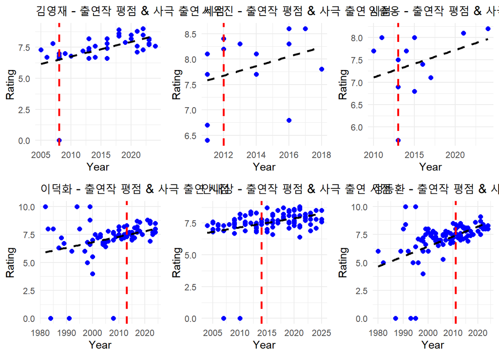

```r
library(dplyr)
library(readr)
library(ggplot2)
library(stringr)
library(gridExtra)
# 1. 데이터 불러오기
final_df <- read_csv("조선왕조_드라마정보_NA최종정제4.csv")
drama_df <- read_csv("drama_info_all.csv")
# 2. base_year 병합
base_year_df <- final_df %>%
  select(actor, base_year = year) %>%
  distinct()

drama_df <- drama_df %>%
  left_join(base_year_df, by = "actor")
# 3. 분석 대상 배우 리스트
selected_actors <- c("김영재", "서우진", "임슬옹",
                     "이덕화", "안내상", "정동환")

# 4. 그래프 생성
plot_list <- list()

for (actor_name in selected_actors) {
  df_actor <- drama_df %>%
    filter(actor == actor_name) %>%
    mutate(
      Year = as.numeric(str_extract(Year, "\\d{4}")),
      Rating = as.numeric(Rating)
    ) %>%
    filter(!is.na(Year), !is.na(Rating))

  if (nrow(df_actor) < 2) next

  base_year <- unique(df_actor$base_year)[1]

  p <- ggplot(df_actor, aes(x = Year, y = Rating)) +
    geom_point(color = "blue", size = 2) +
    geom_smooth(method = "lm", se = FALSE, color = "black", linetype = "dashed", linewidth = 1) +
    { if (!is.na(base_year)) geom_vline(xintercept = base_year, color = "red", linetype = "dashed", linewidth = 1) else NULL } +
    labs(title = paste0(actor_name, " - 출연작 평점 & 사극 출연 시점"),
         x = "Year", y = "Rating") +
    theme_minimal()

  plot_list[[length(plot_list) + 1]] <- p
}

# 5. 2행 4열로 출력
grid.arrange(grobs = plot_list, ncol = 3)
```

⑧-② 각 배우에 대한 종합 점수제 도입

```r
library(dplyr)
library(readr)
library(broom)
library(lubridate)

# 1. 데이터 불러오기 및 정제
df <- read_csv("드라마사극이후.csv") %>%
  mutate(
    Rating = as.numeric(Rating),
    Year = as.numeric(Year)
  ) %>%
  filter(!is.na(Rating), Rating != 0, !is.na(Year), Year != 2025)
# 기준 연도
recent_cutoff <- 2020

# 2. 배우별 점수 계산
score_df <- df %>%
  group_by(actor) %>%
  summarise(
    slope = {
      if (n() >= 2) {
        model <- lm(Rating ~ Year, data = cur_data())
        coef(model)[["Year"]]
      } else {
        NA
      }
    },
    recent_count = sum(Year >= recent_cutoff),
    avg_rating = mean(Rating, na.rm = TRUE),
    max_rating = max(Rating, na.rm = TRUE),
    streak = {
      r <- Rating >= 8.5
      if (length(r) == 0) 0 else max(rle(r)$lengths[rle(r)$values == TRUE], na.rm = TRUE)
    },
    .groups = "drop"
  )
# 3. 점수 정규화
normalize <- function(x, max_score = 10) {
  rng <- range(x, na.rm = TRUE)
  if (diff(rng) == 0) return(rep(0, length(x)))
  return((x - min(x, na.rm = TRUE)) / diff(rng) * max_score)
}

score_df <- score_df %>%
  mutate(
    slope_score = normalize(slope),
    recent_score = pmin(recent_count, 5) / 5 * 10,
    avg_score = avg_rating,        # 평점은 원래 0~10
    max_score = max_rating,        # 최고 평점도 0~10
    streak_score = pmin(streak, 5) / 5 * 10,
    total_score = slope_score + recent_score + avg_score + max_score + streak_score
  ) %>%
  select(actor, total_score, slope_score, recent_score, avg_score, max_score, streak_score)

# 4. 결과 확인

head(score_df, 5)
```

```
## # A tibble: 5 × 7
##   actor  total_score slope_score recent_score avg_score max_score streak_score
##   <chr>        <dbl>       <dbl>        <dbl>     <dbl>     <dbl>        <dbl>
## 1 강태오        36.3        9.32            8      8.11       8.9            2
## 2 김갑수        37.5        6.65           10      7.79       9.1            4
## 3 김기현        27.7        9.31            0      7.8        8.6            2
## 4 김명수        34.9        6.55           10      7.70       8.7            2
## 5 김민기        38.7        7.44           10      8.28       9              4
```

```r
# 5. 저장 (선택)
write_csv(score_df, "배우별_점수제_분석결과.csv")
```

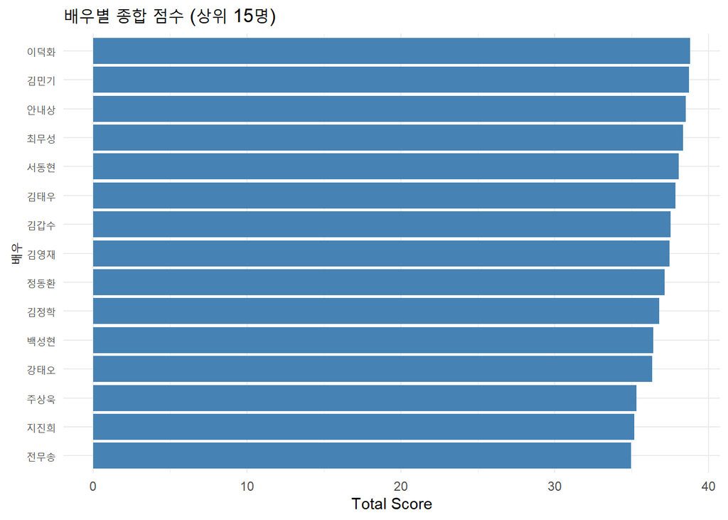

```r
library(ggplot2)

# 상위 15명 기준
top_scores <- score_df %>%
  arrange(desc(total_score)) %>%
  slice_head(n = 15)

# 막대그래프
ggplot(top_scores, aes(x = reorder(actor, total_score), y = total_score)) +
  geom_col(fill = "steelblue") +
  coord_flip() +
  labs(title = "배우별 종합 점수 (상위 15명)",
       x = "배우", y = "Total Score") +
  theme_minimal() +
  theme(text = element_text(family = "NanumGothic"))  # 한글폰트 설정 시 사용
```

⑧- ③ 각 배우의 종합 점수 평가 항목

```r
library(fmsb)
library(dplyr)
library(readr)

# 1️⃣ 점수 데이터 불러오기
score_df <- read_csv("배우별_점수제_분석결과.csv")
```

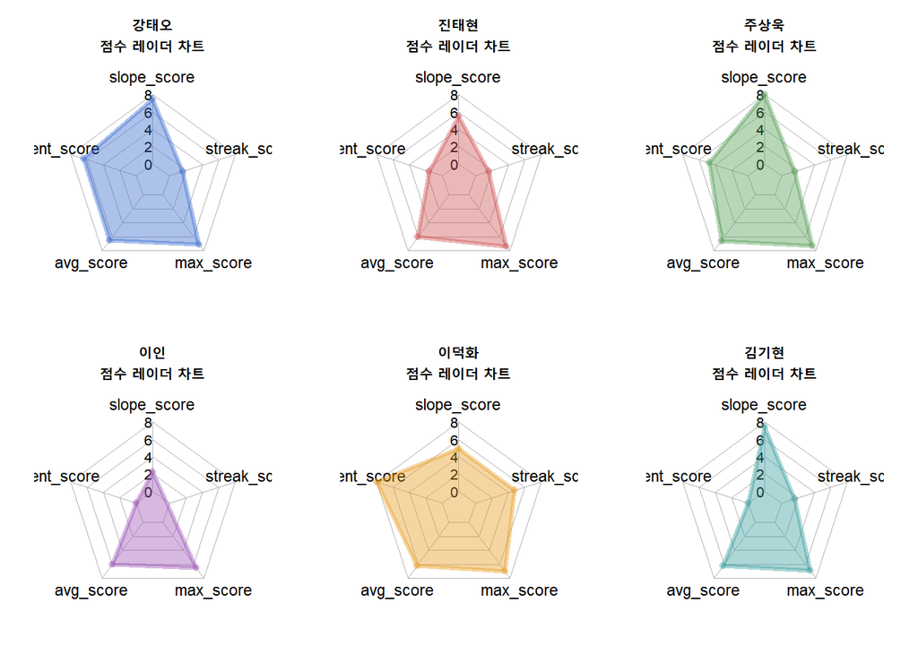

```r
# 2️⃣ 사용할 점수 항목
score_columns <- c("slope_score", "recent_score", "avg_score", "max_score", "streak_score")

# 3️⃣ 대상 배우 목록
selected_actors <- c("강태오", "진태현", "주상욱", "이인", "이덕화", "김기현")

# 4️⃣ 색상 팔레트
color_palette <- c(
  rgb(0.2, 0.4, 0.8, 0.4),
  rgb(0.8, 0.3, 0.3, 0.4),
  rgb(0.3, 0.6, 0.3, 0.4),
  rgb(0.6, 0.3, 0.7, 0.4),
  rgb(0.9, 0.6, 0.1, 0.4),
  rgb(0.2, 0.6, 0.6, 0.4)
)

# 5️⃣ 플롯 창을 2행 3열로 분할
par(mfrow = c(2, 3), mar = c(2, 2, 4, 2))  # 여백 설정 포함

# 6️⃣ 그래프 출력 루프
for (i in seq_along(selected_actors)) {
  actor_name <- selected_actors[i]

  values <- score_df %>%
    filter(actor == actor_name) %>%
    select(all_of(score_columns)) %>%
    mutate(across(everything(), as.numeric)) %>%
    replace(is.na(.), 0)

  radar_data <- rbind(
    max = rep(10, length(score_columns)),
    min = rep(0, length(score_columns)),
    values
  )
  colnames(radar_data) <- score_columns

  fill_color <- color_palette[i]
  line_color <- adjustcolor(fill_color, alpha.f = 1)

  radarchart(
    radar_data,
    axistype = 1,
    pcol = line_color, pfcol = fill_color, plwd = 3, plty = 1,
    cglcol = "grey70", cglty = 1, cglwd = 0.8,
    axislabcol = "black",
    caxislabels = seq(0, 10, 2),
    vlcex = 1.1,
    title = paste0(actor_name, "\n점수 레이더 차트")
  )
}
```

💡 8. 기대 효과 및 활용 캐스팅 디렉터/콘텐츠 기획자가 배우 선정 시 활용 가능

과거 사극 출연 후 커리어 흐름을 시각적으로 이해

배우 전략적 활용과 편성 기준 수립에 기여

추후 장르별, 플랫폼별 분석 확장 가능성 있음